# R Notebook - Meta-analysis by Louise M. Alissa (Sperm Competition Risk)

**ALISSA, L.M. Effect of reproductive site limitation on the intensity of sexual selection and the quality of paternal care: a meta-analysis. 2018. Dissertação (Mestrado) - Instituto de Biociências, Universidade de São Paulo, SP.**

The availability of reproductive sites is a major factor shaping the behavior of males and females in species with resource-based mating systems. Using a meta-analytic approach, we tested five predictions directly or indirectly derived from the mating system theory. We expected that reproductive site limitation would lead to: (1) intense male-male competition for resource possession; (2) high variance in male reproductive success, generating high values of opportunity for sexual selection; (3) high intensity of selection on male traits related to resource possession; (4) high sperm competition risk; and (5) low quality of paternal care. We compiled information from observational and experimental studies that compared the reproductive behavior of individuals of the same species under low and high reproductive site limitation. We found that, when reproductive sites are limited, there is a slight increase in male-male competition, with higher rates of nest takeover and agonistic interactions, and a slight increase in the selection gradient on male traits, with successful males tending to be larger than unsuccessful males. Reproductive site limitation has no consistent effect on the opportunity for sexual selection and on the sperm competition risk. However, territorial males invest more in gonads and lose less paternity when reproductive sites are limited. There is also no clear effect of reproductive site limitation on the quality of paternal care, but few studies have addressed this subject. Taken together, our findings indicate that predictions on how reproductive site limitation affects several aspects of resource-based mating systems have weak empirical support. These predictions do not consider the plasticity in the mating tactics of males and females, which make them too simplistic. Moreover, since the original proposition of the mating system theory, our understanding of sperm competition increased a lot. We now know that accurate predictions on the intensity and direction of sexual selection should take into account both pre- and post-copulatory processes. Finally, the interplay between sexual selection and parental care is complex, and the original framework of mating system theory does not provide sufficient elements to derive clear and taxonomically broad predictions.

Louise Alissa de Morais

e-mail: louisem.alissa@gmail.com

# Organizing

## Loading libraries, setting working directory and loading data set

### Setting the work directory

```r
setwd("C:/Users/louis/Dropbox/Masters_analyses-LMAlissa")
```

### Cleanning possible masking objects

```r
rm(list=ls())
```

### Opening the .csv file

```r
dataset4 <- read.csv(file="basic_dataset4.csv", header=T, dec=".", sep=";")
```

### Looking the data structure

```r
head(dataset4)
```

|  | ES | nID | study | publication_year | species | phylo | class | order | taxon | mating_system | care | male_engagement | exploited_resource | study_type | resource_facet_manipulated | PRED | pred | response_variable | r | N |
| --- | --- | --- | --- | --- | --- | --- | --- | --- | --- | --- | --- | --- | --- | --- | --- | --- | --- | --- | --- | --- |
| 1 | E.S. 01 | 33 | Muniz and Machado 2015 | 2015 | Serracutisoma proximum | Serracutisoma_proximum | Arachnida | Opiliones | 1_artro | polygamy | maternal | no | plant substrate | exp_field | quant | P4 | ART/EPC | mean number of invaders per harem | -0.210000 | 32 |
| 2 | E.S. 02 | 3 | Borg et al 2002 | 2002 | Pomatoschistus microps | Pomatoschistus_microps | Actinopterygii | Perciformes | 2_peixe | polygamy | paternal | yes | bivalves shells | exp_field | quant | P4 | ART/EPC | frequency male sneaking attempts | 0.182316 | 119 |
| 3 | E.S. 03 | 42 | Singer et al 2006 | 2006 | Pomatoschistus minutus | Pomatoschistus_minutus | Actinopterygii | Perciformes | 2_peixe | polygamy | paternal | yes | mussels shells | exp_field | quant | P4 | paternity_loss | mean proportion of nest parazited spawning | 0.231000 | 17 |
| 4 | E.S. 04 | 42 | Singer et al 2006 | 2006 | Pomatoschistus minutus | Pomatoschistus_minutus | Actinopterygii | Perciformes | 2_peixe | polygamy | paternal | yes | mussels shells | exp_field | quant | P4 | paternity_loss | mean proportion of nest parazited spawning | -0.114000 | 16 |
| 5 | E.S. 05 | 42 | Singer et al 2006 | 2006 | Pomatoschistus minutus | Pomatoschistus_minutus | Actinopterygii | Perciformes | 2_peixe | polygamy | paternal | yes | mussels shells | exp_field | quant | P4 | ART/EPC | proportion of males parasitizing others nests | -0.166000 | 17 |
| 6 | E.S. 06 | 42 | Singer et al 2006 | 2006 | Pomatoschistus minutus | Pomatoschistus_minutus | Actinopterygii | Perciformes | 2_peixe | polygamy | paternal | yes | mussels shells | exp_field | quant | P4 | ART/EPC | proportion of males parasitizing others nests | -0.106000 | 16 |

```r
tail(dataset4)
```

|  | ES | nID | study | publication_year | species | phylo | class | order | taxon | mating_system | care | male_engagement | exploited_resource | study_type | resource_facet_manipulated | PRED | pred | response_variable | r | N |
| --- | --- | --- | --- | --- | --- | --- | --- | --- | --- | --- | --- | --- | --- | --- | --- | --- | --- | --- | --- | --- |
| 34 | E.S. 34 | 43 | Stewart et al 2010 | 2010 | Sialia sialis | Sialia_sialis | Aves | Passeriformes | 4_aves | monogamy | biparental | yes | nest box | exp_field | quant | P5 | paternity_loss | cuckoldry occurency (number of brood with at least one extra pair young) | -0.41140284 | 79 |
| 35 | E.S. 35 | 43 | Stewart et al 2010 | 2010 | Sialia sialis | Sialia_sialis | Aves | Passeriformes | 4_aves | monogamy | biparental | yes | nest box | exp_field | quant | P5 | paternity_loss | mean proportion of EPY in broods with EPY | 0.04900000 | 21 |
| 36 | E.S. 36 | 43 | Stewart et al 2010 | 2010 | Sialia sialis | Sialia_sialis | Aves | Passeriformes | 4_aves | monogamy | biparental | yes | nest box | exp_field | quant | P5 | paternity_loss | number of EPY per number of total genotyped nestlings | -0.26699524 | 305 |
| 37 | E.S. 37 | 15 | Garcia-Navas et al 2014 | 2014 | Cyanistes caeruleus | Cyanistes_caeruleus | Aves | Passeriformes | 4_aves | monogamy | biparental | yes | tree hollows and nest box | exp_field | quant | P5 | paternity_loss | ExtraParPaternity rate (in genotyped familys) | 0.18232323 | 17 |
| 38 | E.S. 38 | 48 | Conrad et al 2001 | 2001 | Tachycineta bicolor | Tachycineta_bicolor | Aves | Passeriformes | 4_aves | monogamy | biparental | yes | nest box | exp_field | quant | P5 | paternity_loss | number of nestlings tha are EPY | -0.02406171 | 596 |
| 39 | E.S. 39 | 48 | Conrad et al 2001 | 2001 | Tachycineta bicolor | Tachycineta_bicolor | Aves | Passeriformes | 4_aves | monogamy | biparental | yes | nest box | exp_field | quant | P5 | paternity_loss | broods with EPY | -0.07329426 | 119 |

```r
str(dataset4)
```

```
'data.frame':   39 obs. of  20 variables:
 $ ES                        : Factor w/ 39 levels "E.S. 01","E.S. 02",..: 1 2 3 4 5 6 7 8 9 10 ...
 $ nID                       : int  33 3 42 42 42 42 2 2 2 39 ...
 $ study                     : Factor w/ 19 levels "Bessert et al 2007",..: 14 2 18 18 18 18 1 1 1 16 ...
 $ publication_year          : int  2015 2002 2006 2006 2006 2006 2007 2007 2007 2009 ...
 $ species                   : Factor w/ 13 levels "Cyanistes caeruleus",..: 11 4 5 5 5 5 3 3 3 7 ...
 $ phylo                     : Factor w/ 13 levels "Cyanistes_caeruleus",..: 11 4 5 5 5 5 3 3 3 7 ...
 $ class                     : Factor w/ 3 levels "Actinopterygii",..: 2 1 1 1 1 1 1 1 1 1 ...
 $ order                     : Factor w/ 5 levels "Batrachoidiformes",..: 3 5 5 5 5 5 2 2 2 2 ...
 $ taxon                     : Factor w/ 4 levels "1_artro","2_peixe",..: 1 2 2 2 2 2 2 2 2 2 ...
 $ mating_system             : Factor w/ 2 levels "monogamy","polygamy": 2 2 2 2 2 2 2 2 2 2 ...
 $ care                      : Factor w/ 4 levels "biparental","maternal",..: 2 4 4 4 4 4 4 4 4 3 ...
 $ male_engagement           : Factor w/ 2 levels "no","yes": 1 2 2 2 2 2 2 2 2 1 ...
 $ exploited_resource        : Factor w/ 11 levels "bivalves shells",..: 7 1 4 4 4 4 11 11 11 4 ...
 $ study_type                : Factor w/ 3 levels "exp_field","exp_lab",..: 1 1 1 1 1 1 3 3 3 2 ...
 $ resource_facet_manipulated: Factor w/ 3 levels "dispo","qualit",..: 3 3 3 3 3 3 3 3 3 1 ...
 $ PRED                      : Factor w/ 2 levels "P4","P5": 1 1 1 1 1 1 2 2 2 2 ...
 $ pred                      : Factor w/ 3 levels "ART/EPC","gonadal_investiment",..: 1 1 3 3 1 1 3 3 3 2 ...
 $ response_variable         : Factor w/ 31 levels "broods with EPY",..: 12 5 16 16 29 29 9 8 13 10 ...
 $ r                         : num  -0.21 0.182 0.231 -0.114 -0.166 ...
 $ N                         : int  32 119 17 16 17 16 42 42 35 20 ...
```

### Setting the rigth classes for variables

```r
dataset4$nID <- as.factor(dataset4$nID)
dataset4$publication_year <- as.factor(dataset4$publication_year)
str(dataset4)
```

```
'data.frame':   39 obs. of  20 variables:
 $ ES                        : Factor w/ 39 levels "E.S. 01","E.S. 02",..: 1 2 3 4 5 6 7 8 9 10 ...
 $ nID                       : Factor w/ 19 levels "2","3","7","8",..: 11 2 14 14 14 14 1 1 1 12 ...
 $ study                     : Factor w/ 19 levels "Bessert et al 2007",..: 14 2 18 18 18 18 1 1 1 16 ...
 $ publication_year          : Factor w/ 14 levels "1991","2000",..: 14 4 7 7 7 7 8 8 8 9 ...
 $ species                   : Factor w/ 13 levels "Cyanistes caeruleus",..: 11 4 5 5 5 5 3 3 3 7 ...
 $ phylo                     : Factor w/ 13 levels "Cyanistes_caeruleus",..: 11 4 5 5 5 5 3 3 3 7 ...
 $ class                     : Factor w/ 3 levels "Actinopterygii",..: 2 1 1 1 1 1 1 1 1 1 ...
 $ order                     : Factor w/ 5 levels "Batrachoidiformes",..: 3 5 5 5 5 5 2 2 2 2 ...
 $ taxon                     : Factor w/ 4 levels "1_artro","2_peixe",..: 1 2 2 2 2 2 2 2 2 2 ...
 $ mating_system             : Factor w/ 2 levels "monogamy","polygamy": 2 2 2 2 2 2 2 2 2 2 ...
 $ care                      : Factor w/ 4 levels "biparental","maternal",..: 2 4 4 4 4 4 4 4 4 3 ...
 $ male_engagement           : Factor w/ 2 levels "no","yes": 1 2 2 2 2 2 2 2 2 1 ...
 $ exploited_resource        : Factor w/ 11 levels "bivalves shells",..: 7 1 4 4 4 4 11 11 11 4 ...
 $ study_type                : Factor w/ 3 levels "exp_field","exp_lab",..: 1 1 1 1 1 1 3 3 3 2 ...
 $ resource_facet_manipulated: Factor w/ 3 levels "dispo","qualit",..: 3 3 3 3 3 3 3 3 3 1 ...
 $ PRED                      : Factor w/ 2 levels "P4","P5": 1 1 1 1 1 1 2 2 2 2 ...
 $ pred                      : Factor w/ 3 levels "ART/EPC","gonadal_investiment",..: 1 1 3 3 1 1 3 3 3 2 ...
 $ response_variable         : Factor w/ 31 levels "broods with EPY",..: 12 5 16 16 29 29 9 8 13 10 ...
 $ r                         : num  -0.21 0.182 0.231 -0.114 -0.166 ...
 $ N                         : int  32 119 17 16 17 16 42 42 35 20 ...
```

## Loanding and dealing with the phylogeny

### First, opening the file .tree (newik). The tree was constructed on Mesquite.

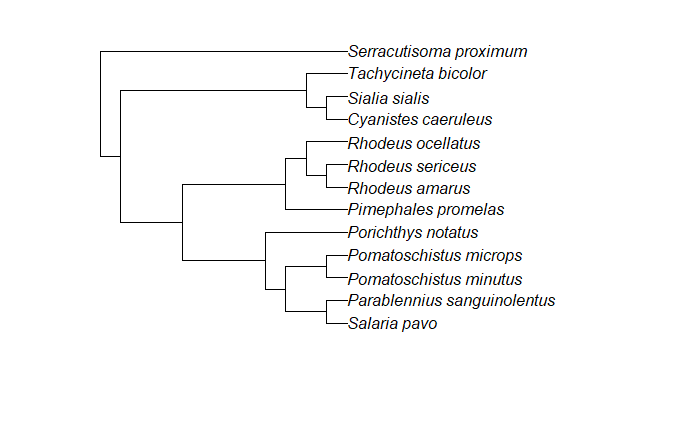

```r
tree4 <- read.tree('mytree4_mod.tre')
plot(tree4)
```

### Calculating the correlation matrix, with weighted values for relatedness

```r
tree4_mod <- compute.brlen(tree4, method="Grafen")
cor <- vcv(tree4_mod, corr =T)
```

### Cheking if every specie in the data is present in the tree

```r
spp <- data.frame(spp = unique(dataset4$phylo))
row.names(spp) <- spp$spp
```

```r
check.phylo <- name.check(tree4_mod, spp)
check.phylo
```

```
[1] "OK"
```

## Transforming r in Fisher’s Z

In our table we have values of r, here we transform to Z

```r
dataset4 <- escalc(measure="ZCOR", ri=r, ni=N, data=dataset4, append=TRUE)
attach(dataset4)
```

# Selecting the random-effects based on AICc

Randon variables: the effect size identity (id.mc), the article identity(nID), species (species) and the phylogenetic effect (phylo). Without moderators here.

### Creating an object for list each effect size

```r
id.sc <- as.factor(1:(length(dataset4$r)))
```

### Constructing models

```r
# id |--> AICc =  7.1727
m_randon1 <- rma.mv(yi=yi, V=vi, random = list(~ 1|id.sc), data=dataset4, method="ML")
summary(m_randon1)
```

```
Multivariate Meta-Analysis Model (k = 39; method: ML)

  logLik  Deviance       AIC       BIC      AICc
 -1.4197   81.2003    6.8394   10.1665    7.1727

Variance Components:

            estim    sqrt  nlvls  fixed  factor
sigma^2    0.0332  0.1821     39     no   id.sc

Test for Heterogeneity:
Q(df = 38) = 119.3021, p-val < .0001

Model Results:

estimate      se     zval    pval    ci.lb   ci.ub
 -0.0675  0.0383  -1.7621  0.0781  -0.1425  0.0076  .

---
Signif. codes:  0 *** 0.001 ** 0.01 * 0.05 . 0.1   1
```

```r
# id + phylo |--> AICc = 8.7932
m_randon2 <- rma.mv(yi=yi, V=vi, random = list(~ 1|id.sc, ~1|phylo),R=list(phylo=cor), data=dataset4, method="ML")
summary(m_randon2)
```

```
Multivariate Meta-Analysis Model (k = 39; method: ML)

  logLik  Deviance       AIC       BIC      AICc
 -1.0538   80.4684    8.1075   13.0982    8.7932

Variance Components:

            estim    sqrt  nlvls  fixed  factor    R
sigma^2.1  0.0268  0.1636     39     no   id.sc   no
sigma^2.2  0.0115  0.1073     13     no   phylo  yes

Test for Heterogeneity:
Q(df = 38) = 119.3021, p-val < .0001

Model Results:

estimate      se     zval    pval    ci.lb   ci.ub
 -0.0561  0.0750  -0.7481  0.4544  -0.2031  0.0909

---
Signif. codes:  0 *** 0.001 ** 0.01 * 0.05 . 0.1   1
```

```r
# id + species |--> AICc = 6.7595
m_randon3 <- rma.mv(yi=yi, V=vi, random = list(~ 1|id.sc, ~1|species), data=dataset4, method="ML")
summary(m_randon3)
```

```
Multivariate Meta-Analysis Model (k = 39; method: ML)

  logLik  Deviance       AIC       BIC      AICc
 -0.0369   78.4347    6.0738   11.0645    6.7595

Variance Components:

            estim    sqrt  nlvls  fixed   factor
sigma^2.1  0.0189  0.1373     39     no    id.sc
sigma^2.2  0.0210  0.1450     13     no  species

Test for Heterogeneity:
Q(df = 38) = 119.3021, p-val < .0001

Model Results:

estimate      se     zval    pval    ci.lb   ci.ub
 -0.0297  0.0578  -0.5132  0.6078  -0.1429  0.0836

---
Signif. codes:  0 *** 0.001 ** 0.01 * 0.05 . 0.1   1
```

```r
# id + nID |--> AICc = 9.5251
m_randon4 <- rma.mv(yi=yi, V=vi, random = list(~ 1|id.sc, ~1|nID), data=dataset4, method="ML")
summary(m_randon4)
```

```
Multivariate Meta-Analysis Model (k = 39; method: ML)

  logLik  Deviance       AIC       BIC      AICc
 -1.4197   81.2003    8.8394   13.8301    9.5251

Variance Components:

            estim    sqrt  nlvls  fixed  factor
sigma^2.1  0.0332  0.1821     39     no   id.sc
sigma^2.2  0.0000  0.0000     19     no     nID

Test for Heterogeneity:
Q(df = 38) = 119.3021, p-val < .0001

Model Results:

estimate      se     zval    pval    ci.lb   ci.ub
 -0.0675  0.0383  -1.7621  0.0781  -0.1425  0.0076  .

---
Signif. codes:  0 *** 0.001 ** 0.01 * 0.05 . 0.1   1
```

```r
# id + specie + phylo |--> AICc = 9.2503
m_randon5 <- rma.mv(yi=yi, V=vi, random = list(~ 1|id.sc, ~1|species, ~1|phylo), R=list(phylo=cor), data=dataset4, method="ML")
summary(m_randon5)
```

```
Multivariate Meta-Analysis Model (k = 39; method: ML)

  logLik  Deviance       AIC       BIC      AICc
 -0.0369   78.4347    8.0738   14.7281    9.2503

Variance Components:

            estim    sqrt  nlvls  fixed   factor    R
sigma^2.1  0.0189  0.1373     39     no    id.sc   no
sigma^2.2  0.0210  0.1450     13     no  species   no
sigma^2.3  0.0000  0.0000     13     no    phylo  yes

Test for Heterogeneity:
Q(df = 38) = 119.3021, p-val < .0001

Model Results:

estimate      se     zval    pval    ci.lb   ci.ub
 -0.0297  0.0578  -0.5132  0.6078  -0.1429  0.0836

---
Signif. codes:  0 *** 0.001 ** 0.01 * 0.05 . 0.1   1
```

```r
# id + nID + specie |--> AICc = 9.2503
m_randon6 <- rma.mv(yi=yi, V=vi, random = list(~ 1|id.sc, ~1|nID, ~1|species), data=dataset4, method="ML")
summary(m_randon6)
```

```
Multivariate Meta-Analysis Model (k = 39; method: ML)

  logLik  Deviance       AIC       BIC      AICc
 -0.0369   78.4347    8.0738   14.7281    9.2503

Variance Components:

            estim    sqrt  nlvls  fixed   factor
sigma^2.1  0.0189  0.1373     39     no    id.sc
sigma^2.2  0.0000  0.0000     19     no      nID
sigma^2.3  0.0210  0.1450     13     no  species

Test for Heterogeneity:
Q(df = 38) = 119.3021, p-val < .0001

Model Results:

estimate      se     zval    pval    ci.lb   ci.ub
 -0.0297  0.0578  -0.5132  0.6078  -0.1429  0.0836

---
Signif. codes:  0 *** 0.001 ** 0.01 * 0.05 . 0.1   1
```

```r
# id + nID + phylo |--> AICc = 11.2840
m_randon7 <- rma.mv(yi=yi, V=vi, random = list(~ 1|id.sc, ~1|nID, ~1|phylo),R=list(phylo=cor), data=dataset4, method="ML")
summary(m_randon7)
```

```
Multivariate Meta-Analysis Model (k = 39; method: ML)

  logLik  Deviance       AIC       BIC      AICc
 -1.0538   80.4684   10.1075   16.7618   11.2840

Variance Components:

            estim    sqrt  nlvls  fixed  factor    R
sigma^2.1  0.0268  0.1636     39     no   id.sc   no
sigma^2.2  0.0000  0.0000     19     no     nID   no
sigma^2.3  0.0115  0.1073     13     no   phylo  yes

Test for Heterogeneity:
Q(df = 38) = 119.3021, p-val < .0001

Model Results:

estimate      se     zval    pval    ci.lb   ci.ub
 -0.0561  0.0750  -0.7481  0.4544  -0.2031  0.0909

---
Signif. codes:  0 *** 0.001 ** 0.01 * 0.05 . 0.1   1
```

```r
# id + nID + specie + phylo |--> AICc = 11.8920
m_randon8 <- rma.mv(yi=yi, V=vi, random = list(~ 1|id.sc, ~1|nID, ~1|species, ~1|phylo), R=list(phylo=cor), data=dataset4, method="ML")
summary(m_randon8)
```

```
Multivariate Meta-Analysis Model (k = 39; method: ML)

  logLik  Deviance       AIC       BIC      AICc
 -0.0369   78.4347   10.0738   18.3916   11.8920

Variance Components:

            estim    sqrt  nlvls  fixed   factor    R
sigma^2.1  0.0189  0.1373     39     no    id.sc   no
sigma^2.2  0.0000  0.0000     19     no      nID   no
sigma^2.3  0.0210  0.1450     13     no  species   no
sigma^2.4  0.0000  0.0000     13     no    phylo  yes

Test for Heterogeneity:
Q(df = 38) = 119.3021, p-val < .0001

Model Results:

estimate      se     zval    pval    ci.lb   ci.ub
 -0.0297  0.0578  -0.5132  0.6078  -0.1429  0.0836

---
Signif. codes:  0 *** 0.001 ** 0.01 * 0.05 . 0.1   1
```

### Creating a table to compare models, looking for AICc

```r
ICtab(m_randon1, m_randon2, m_randon3, m_randon4, m_randon5, m_randon7, m_randon8, type= "AICc")
```

```
          dAICc df
m_randon3 0.0   3
m_randon1 0.4   2
m_randon2 2.0   3
m_randon5 2.5   4
m_randon4 2.8   3
m_randon7 4.5   4
m_randon8 5.1   5
```

# Performing - data set 4 -Sperm Competition

## The meta-analytic model

Randon variables: the effect size identity, the article identity, species and the phylogenetic effect. Without moderators here

```r
meta.sc.phylo <- rma.mv(yi=yi, V=vi, random = list(~ 1|id.sc, ~1|nID, ~1|species, ~1|phylo), R=list(phylo=cor) , data=dataset4, method="REML")
```

### Looking the results

```r
summary(meta.sc.phylo)
```

```
Multivariate Meta-Analysis Model (k = 39; method: REML)

  logLik  Deviance       AIC       BIC      AICc
  0.0014   -0.0029    9.9971   18.1850   11.8721

Variance Components:

            estim    sqrt  nlvls  fixed   factor    R
sigma^2.1  0.0189  0.1373     39     no    id.sc   no
sigma^2.2  0.0000  0.0000     19     no      nID   no
sigma^2.3  0.0188  0.1372     13     no  species   no
sigma^2.4  0.0097  0.0986     13     no    phylo  yes

Test for Heterogeneity:
Q(df = 38) = 119.3021, p-val < .0001

Model Results:

estimate      se     zval    pval    ci.lb   ci.ub
 -0.0390  0.0809  -0.4821  0.6298  -0.1976  0.1196

---
Signif. codes:  0 *** 0.001 ** 0.01 * 0.05 . 0.1   1
```

### Overall effect and CI converted back to “r”

```r
predict(meta.sc.phylo, transf=transf.ztor)#  overall effect and CI converted back to "r"
```

```
    pred   ci.lb  ci.ub   cr.lb  cr.ub
 -0.0390 -0.1951 0.1190 -0.4576 0.3937
```

### Basic forest plot (made with metafor package)

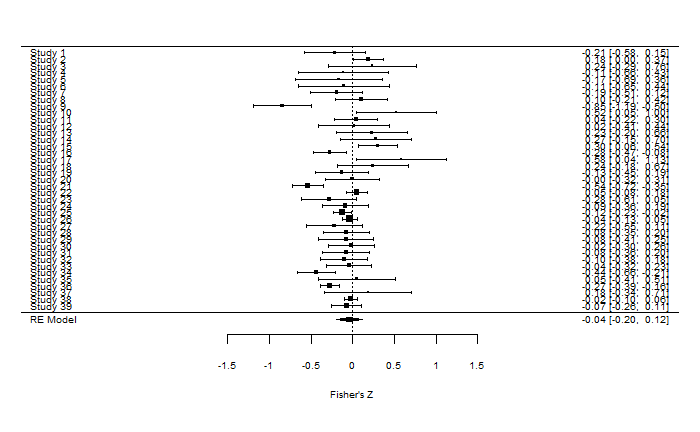

```r
forest(meta.sc.phylo, cex=.6, xlab="Fisher's Z")
```

## Heterogeinity

*Based in Nakagawa & Santos (2012)*

```r
s2m.sc <- sum(1/meta.sc.phylo$vi) * (meta.sc.phylo$k-1) / (sum(1/meta.sc.phylo$vi)^2 - sum((1/meta.sc.phylo$vi)^2))
s2m.sc #s^2_m variation within study
```

```
[1] 0.01208726
```

```r
s2t.sc <- sum(meta.sc.phylo$sigma2) + s2m.sc
s2t.sc #s^2_t variation total
```

```
[1] 0.05948572
```

### The total amount of variance

```r
total_I2.sc <- sum(meta.sc.phylo$sigma2)/s2t.sc
total_I2.sc*100 # the "total" variation
```

```
[1] 79.68041
```

### Proportion of variance from effect size id

```r
id.sc_I2 <- meta.sc.phylo$sigma2[1]/s2t.sc
id.sc_I2*100
```

```
[1] 31.69328
```

### Proportion of variance from study id

```r
nID_I2 <- meta.sc.phylo$sigma2[2]/s2t.sc
nID_I2*100
```

```
[1] 0
```

### Proportion of variance from species id

```r
especies_I2 <- meta.sc.phylo$sigma2[3]/s2t.sc
especies_I2*100
```

```
[1] 31.64148
```

### Proportion of variance from phylo

```r
phylo_I2 <- meta.sc.phylo$sigma2[4]/s2t.sc
phylo_I2*100
```

```
[1] 16.34565
```

Moderate, in this case.

```r
H2.sc<-meta.sc.phylo$sigma2[4] / sum(meta.sc.phylo$sigma2)
H2.sc*100
```

```
[1] 20.51402
```

## Qb

Testing if the mean effect is different in different taxa.

```r
mean_taxon <- rma.mv(yi=yi, V=vi, random = list(~ 1|id.sc, ~1|nID, ~1|species, ~1|phylo), R=list(phylo=cor) , data=dataset4, method="REML", mod= ~ taxon-1)
summary(mean_taxon)
```

```
Multivariate Meta-Analysis Model (k = 39; method: REML)

  logLik  Deviance       AIC       BIC      AICc
  0.3941   -0.7883   15.2117   27.6545   20.7502

Variance Components:

            estim    sqrt  nlvls  fixed   factor    R
sigma^2.1  0.0197  0.1403     39     no    id.sc   no
sigma^2.2  0.0000  0.0000     19     no      nID   no
sigma^2.3  0.0254  0.1595     13     no  species   no
sigma^2.4  0.0000  0.0000     13     no    phylo  yes

Test for Residual Heterogeneity:
QE(df = 35) = 110.0441, p-val < .0001

Test of Moderators (coefficient(s) 1:4):
QM(df = 4) = 2.7320, p-val = 0.6036

Model Results:

              estimate      se     zval    pval    ci.lb   ci.ub
taxon1_artro   -0.2132  0.2821  -0.7556  0.4499  -0.7662  0.3398
taxon2_peixe    0.0566  0.0809   0.7003  0.4837  -0.1018  0.2151
taxon2_pisc    -0.0186  0.1923  -0.0965  0.9231  -0.3954  0.3583
taxon4_aves    -0.1312  0.1036  -1.2670  0.2052  -0.3342  0.0718

---
Signif. codes:  0 *** 0.001 ** 0.01 * 0.05 . 0.1   1
```

# Testing publication bias

## Egger’s regression

### Radial figure

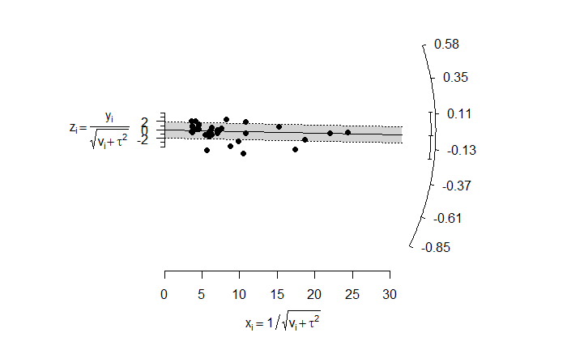

```r
# Egger's figure
radial.rma(meta.sc.phylo)
```

### Egger’s regression test

Not significant

```r
# Another way to calculate Egger's regresiion
s.e.sc <- sqrt(dataset4$vi)
precision.sc <- 1/s.e.sc
Egger.sc <- lm(dataset4$yi*precision.sc ~ precision.sc)
summary(Egger.sc)
```

```
Call:
lm(formula = dataset4$yi * precision.sc ~ precision.sc)

Residuals:
    Min      1Q  Median      3Q     Max
-4.7993 -0.5404  0.0772  1.1108  3.0433

Coefficients:
             Estimate Std. Error t value Pr(>|t|)
(Intercept)   0.33006    0.53580   0.616   0.5417
precision.sc -0.11124    0.05722  -1.944   0.0595 .
---
Signif. codes:  0 *** 0.001 ** 0.01 * 0.05 . 0.1   1

Residual standard error: 1.787 on 37 degrees of freedom
Multiple R-squared:  0.09269,   Adjusted R-squared:  0.06817
F-statistic:  3.78 on 1 and 37 DF,  p-value: 0.0595
```

## Funnel Plot

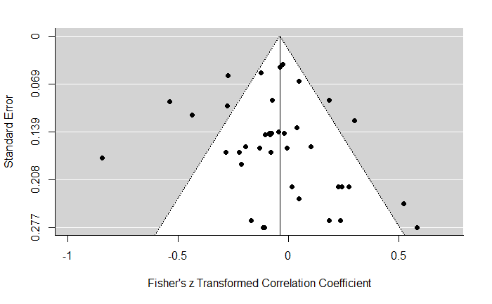

```r
# Basic funnel plot
funnel(meta.sc.phylo)
```

```r
#plot 1 ("plot")
plot(dataset4$yi,
     precision.sc,
     xlab="Fisher's Z",
     ylab="precision (1/s.e.)",
     cex=1.5,
     xlim=c(min(dataset4$yi, na.rm=T)-0.5,max(dataset4$yi, na.rm=T)+0.5),
     ylim=c(0,max(precision.sc, na.rm=T)*1.2))
abline(v=meta.sc.phylo[1], lwd=3)
```

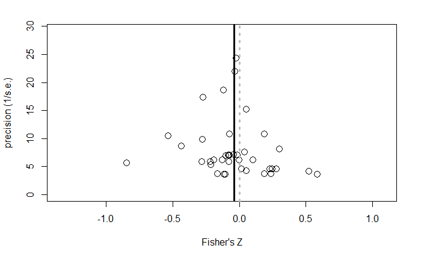

```r
abline(v=0, col=8, lwd=3, lty="dotted")
```

```r
#plot 2 ("ggplot")
dataset4$precision.sc <-precision.sc
funnel_4 <- ggplot(dataset4, aes(x=yi, y=precision.sc)) +
  geom_point(size=4, colour="gray30") +
  scale_shape(solid=FALSE) +
  xlab(expression("Fisher's "*italic(Z))) +
  ylab("precision (1/s.e.)") +
  theme_classic(base_size = 23)+
  geom_vline(xintercept=0, size=1.1, colour="gray", linetype = 1)+
  geom_vline(xintercept=0.1663, size=1.1, linetype = 1)+
  theme(axis.title.x=element_text(vjust=-0.1))+
  theme(axis.title.y=element_text(vjust=1.2))
```

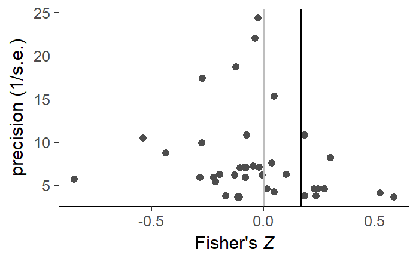

```r
funnel_4
```

# Moderators

## Type of methodological approach

Testing if differences between study methods (obs, exp_lab, exp_field) explain variance in data

```r
meta.sc_mod1 <- rma.mv(yi=yi, V=vi, random = list(~ 1|id.sc, ~1|nID, ~1|species, ~1|phylo), R=list(phylo=cor) , data=dataset4, method="REML", mod= ~ study_type-1)
summary(meta.sc_mod1)
```

```
Multivariate Meta-Analysis Model (k = 39; method: REML)

  logLik  Deviance       AIC       BIC      AICc
  2.0815   -4.1629    9.8371   20.9217   13.8371

Variance Components:

            estim    sqrt  nlvls  fixed   factor    R
sigma^2.1  0.0208  0.1442     39     no    id.sc   no
sigma^2.2  0.0000  0.0000     19     no      nID   no
sigma^2.3  0.0017  0.0413     13     no  species   no
sigma^2.4  0.0278  0.1667     13     no    phylo  yes

Test for Residual Heterogeneity:
QE(df = 36) = 107.0936, p-val < .0001

Test of Moderators (coefficient(s) 1:3):
QM(df = 3) = 5.8439, p-val = 0.1195

Model Results:

                     estimate      se     zval    pval    ci.lb   ci.ub
study_typeexp_field   -0.0971  0.1189  -0.8169  0.4140  -0.3302  0.1359
study_typeexp_lab      0.2556  0.1830   1.3964  0.1626  -0.1032  0.6143
study_typeobs         -0.1531  0.1350  -1.1338  0.2569  -0.4178  0.1116

---
Signif. codes:  0 *** 0.001 ** 0.01 * 0.05 . 0.1   1
```

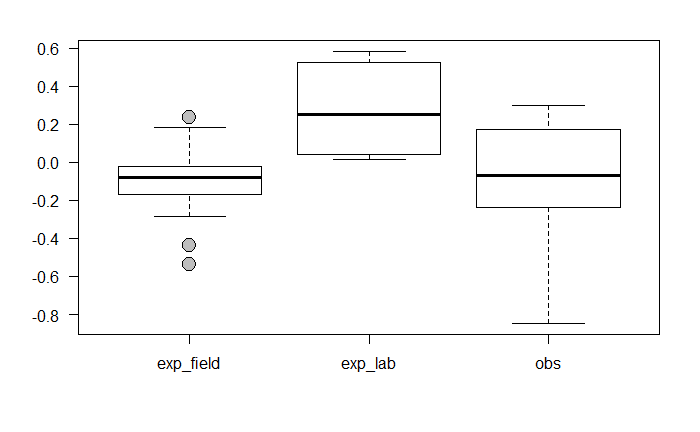

```r
plot(dataset4$study_type, dataset4$yi, las = 1, bty = "l", cex = 2, pch=21, bg=16)
```

```r
table(dataset4$study_type)
```

```
exp_field   exp_lab       obs
       25         6         8
```

## Type of mating system

Testing if differences between monogamy and polygamy mating systems explain variance in data

```r
meta.sc_mod22 <- rma.mv(yi=yi, V=vi, random = list(~ 1|id.sc, ~1|nID, ~1|species, ~1|phylo), R=list(phylo=cor) , data=dataset4, method="REML", mod= ~ mating_system-1)
summary(meta.sc_mod22)
```

```
Multivariate Meta-Analysis Model (k = 39; method: REML)

  logLik  Deviance       AIC       BIC      AICc
  0.0858   -0.1715   11.8285   21.4940   14.6285

Variance Components:

            estim    sqrt  nlvls  fixed   factor    R
sigma^2.1  0.0205  0.1430     39     no    id.sc   no
sigma^2.2  0.0000  0.0000     19     no      nID   no
sigma^2.3  0.0204  0.1428     13     no  species   no
sigma^2.4  0.0000  0.0000     13     no    phylo  yes

Test for Residual Heterogeneity:
QE(df = 37) = 112.8217, p-val < .0001

Test of Moderators (coefficient(s) 1:2):
QM(df = 2) = 1.4108, p-val = 0.4939

Model Results:

                       estimate      se     zval    pval    ci.lb   ci.ub
mating_systemmonogamy   -0.0966  0.0848  -1.1386  0.2549  -0.2629  0.0697
mating_systempolygamy    0.0026  0.0656   0.0393  0.9686  -0.1261  0.1312

---
Signif. codes:  0 *** 0.001 ** 0.01 * 0.05 . 0.1   1
```

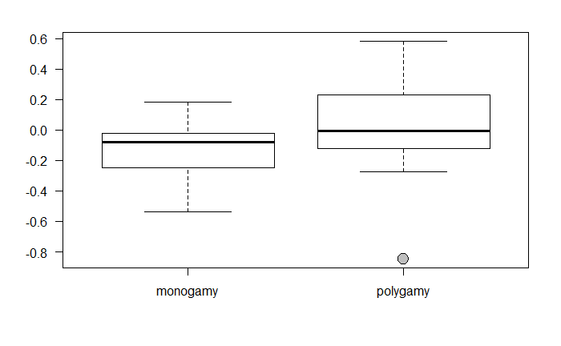

```r
plot(dataset4$mating_system, dataset4$yi, las = 1, bty = "l", cex = 2, pch=21, bg=16)
```

```r
table(dataset4$mating_system)
```

```
monogamy polygamy
      16       23
```

## Type of parental care

Testing if differences between parental care type (maternal, paternal, biparental, no_care) explain variance in data

```r
meta.sc_mod3 <- rma.mv(yi=yi, V=vi, random = list(~ 1|id.sc, ~1|nID, ~1|species, ~1|phylo), R=list(phylo=cor) , data=dataset4, method="REML", mod= ~ care-1)
summary(meta.sc_mod3)
```

```
Multivariate Meta-Analysis Model (k = 39; method: REML)

  logLik  Deviance       AIC       BIC      AICc
  2.6420   -5.2839   10.7161   23.1588   16.2545

Variance Components:

            estim    sqrt  nlvls  fixed   factor    R
sigma^2.1  0.0190  0.1380     39     no    id.sc   no
sigma^2.2  0.0000  0.0000     19     no      nID   no
sigma^2.3  0.0000  0.0000     13     no  species   no
sigma^2.4  0.0715  0.2674     13     no    phylo  yes

Test for Residual Heterogeneity:
QE(df = 35) = 104.3810, p-val < .0001

Test of Moderators (coefficient(s) 1:4):
QM(df = 4) = 4.2734, p-val = 0.3703

Model Results:

                estimate      se     zval    pval    ci.lb   ci.ub
carebiparental   -0.1223  0.2592  -0.4717  0.6371  -0.6302  0.3857
carematernal     -0.2132  0.3536  -0.6028  0.5466  -0.9062  0.4799
careno_care       0.3093  0.2618   1.1811  0.2375  -0.2039  0.8224
carepaternal     -0.1023  0.2186  -0.4679  0.6399  -0.5307  0.3262

---
Signif. codes:  0 *** 0.001 ** 0.01 * 0.05 . 0.1   1
```

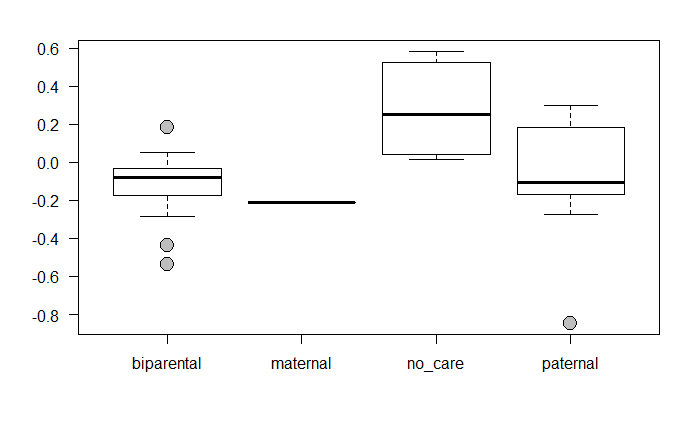

```r
plot(dataset4$care, dataset4$yi, las = 1, bty = "l", cex = 2, pch=21, bg=16)
```

```r
table(dataset4$care)
```

```
biparental   maternal    no_care   paternal
        19          1          6         13
```

## Pred

Testing if the type of proxy explain the variance

```r
# pred
meta.sc_mod4 <- rma.mv(yi=yi, V=vi, random = list(~ 1|id.sc, ~1|nID, ~1|species, ~1|phylo), R=list(phylo=cor) , data=dataset4, method="REML", mod= ~ pred-1)
summary(meta.sc_mod4)
```

```
Multivariate Meta-Analysis Model (k = 39; method: REML)

  logLik  Deviance       AIC       BIC      AICc
  3.5383   -7.0767    6.9233   18.0079   10.9233

Variance Components:

            estim    sqrt  nlvls  fixed   factor    R
sigma^2.1  0.0203  0.1424     39     no    id.sc   no
sigma^2.2  0.0000  0.0000     19     no      nID   no
sigma^2.3  0.0028  0.0528     13     no  species   no
sigma^2.4  0.0000  0.0000     13     no    phylo  yes

Test for Residual Heterogeneity:
QE(df = 36) = 93.8082, p-val < .0001

Test of Moderators (coefficient(s) 1:3):
QM(df = 3) = 14.9925, p-val = 0.0018

Model Results:

                         estimate      se     zval    pval    ci.lb    ci.ub
predART/EPC                0.0545  0.0833   0.6546  0.5127  -0.1087   0.2177
predgonadal_investiment    0.2289  0.1106   2.0684  0.0386   0.0120   0.4457   *
predpaternity_loss        -0.1515  0.0474  -3.1990  0.0014  -0.2443  -0.0587  **

---
Signif. codes:  0 *** 0.001 ** 0.01 * 0.05 . 0.1   1
```

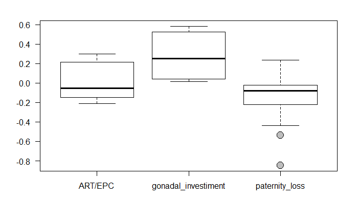

```r
plot(dataset4$pred, dataset4$yi, las = 1, bty = "l", cex = 2, pch=21, bg=16)
```

```r
table(dataset4$pred)
```

```
            ART/EPC gonadal_investiment      paternity_loss
                  8                   6                  25
```

# Making a better forest plot

```r
mean.effect <- as.data.frame(matrix(t(mean.effect),nrow=1),stringsAsFactors=FALSE)
class(mean.effect)
```

```
[1] "data.frame"
```

```r
df4.4$yi <- as.character(df4.4$yi)
df4.4$CILB <- as.character(df4.4$CILB)
df4.4$CIUB <- as.character(df4.4$CIUB)
```

```r
df4.4$yi <- as.numeric(df4.4$yi)
df4.4$CILB <- as.numeric(df4.4$CILB)
df4.4$CIUB <- as.numeric(df4.4$CIUB)
```

```r
highlight <- subset(df4.4, ES=="Mean effect size")
```

Now, creating the plot

```r
myplot_4 <- ggplot(df4.4, aes(x=ES)) +
  geom_hline(aes(yintercept=0), linetype="dashed", color="gray", lwd=1) +
  geom_linerange(aes(x=ES, ymin=CILB, ymax=CIUB),col="gray50", lwd=1, alpha=0.7) +
  geom_linerange(aes(x=ES, ymin=CILB, ymax=CIUB), data=highlight, colour="black") +
  geom_point(aes(y=yi, size=yi), shape = 21, fill="gray50", col="gray50") +
  geom_point(aes(y=yi, size=yi), data=highlight, colour="black") +
  scale_size_continuous(range = c(1,5), name="Effect size Zr") +
  scale_x_discrete(limits = rev(levels(df4.4$ES)))+
  ylab(expression(Effect~Size~italic(Zr)))+
  xlab("")+
  theme_bw()+
  coord_flip()+
  guides(fill= guide_legend(override.aes = list(size=5)),
         size = guide_legend(override.aes = list(fill = "gray40")))+
  theme(panel.border = element_blank(),
        panel.grid.major = element_blank(),
        panel.grid.minor = element_blank(),
        axis.text.x = element_text(size=12),
        axis.text.y = element_text(size=10),
        axis.line = element_line(colour = "black"),
        legend.position = "none")
```

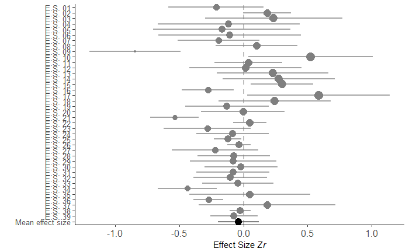

```r
myplot_4
```